# Aderência entre o Parlamentar e seu Partido

## Aderência de deputados à orientação dos partidos

Nesta análise estamos interessados em entender um pouco mais sobre como os Deputados Federais atuam em votações realizadas em Plenário. Quais os deputados que mais seguem a orientação do partido? E os que menos seguem? Quais os partidos que possuem deputados mais aderentes?

Essas são algumas perguntas que podemos responder olhando os dados de **votações realizadas em plenário** para o ano de **2019**. Portanto, todos os deputados analisados aqui participaram da legislatura atual da Câmara dos Deputados (legislatura 56).

Foram consideradas 19 proposições que, segundo a API da Câmara dos Deputados, tiveram votações realizadas em plenário no ano de 2019. Lista completa disponível [aqui](https://www.camara.leg.br/SitCamaraWS/Proposicoes.asmx/ListarProposicoesVotadasEmPlenario?ano=2019&tipo=).

Essas proposições geraram 93 votações em plenário. Capturamos os resultados de todas essas votações observando principalmente: o **voto do deputado** e a **orientação do partido**.

Para cada votação de cada deputado calculamos se ele seguiu a orientação do partido ou não. Em seguida, calculamos o grau de aderência dos deputados a seus respectivos partidos através da equação: *nº de votações em que seguiu / (nº de votações em que seguiu + nº de votacoes em que não seguiu)*.

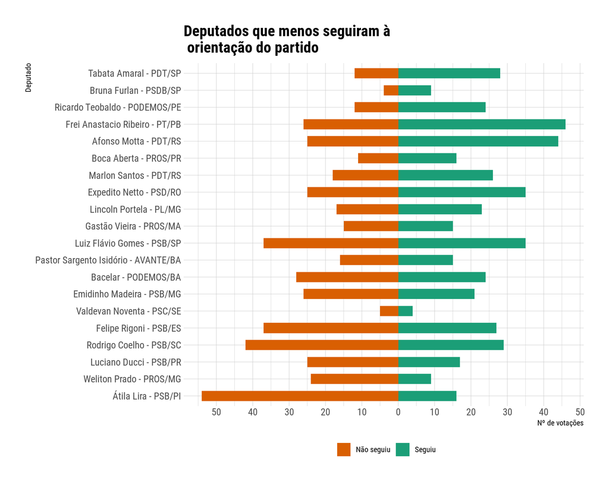

Acima temos a informações dos 20 deputados que possuem menor aderência com o partido. Ou seja, que menos seguem a orientação do partido considerando o total de votações em que participou. Podemos usar o exemplo de Átila Lira PSB/PI para entender como ler a visualização. Ele seguiu o partido em 16 votações e não seguiu em 54 votações. A aderência para Átila é de 16 / (16 + 54), isto é 23%. Para resumir, em 23% das votações Átila segue o partido.

As barras têm comprimento diferente pois os deputados tem um número diferente de votações nas quais participaram. A ordenação definida coloca os deputados da maior aderência para a menor. **Não foram mostradas na visualização votações em que o partido liberou seus membros para votar como preferir.**

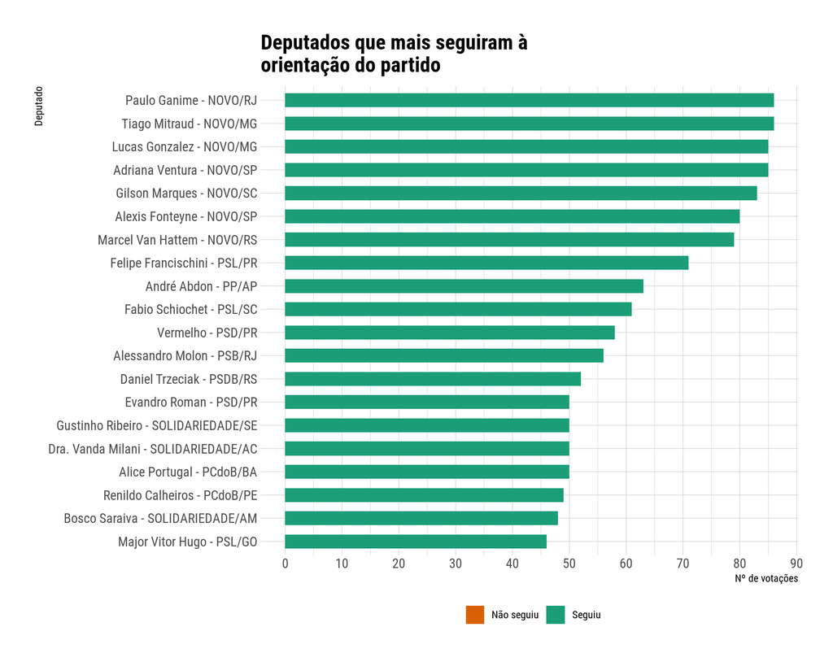

Se olharmos para os deputados com maiores valores de aderência (apenas os 20 primeiros) temos a lista apresentada acima. Todos estes deputados tiveram aderência igual a 100%, ou seja, seguiram todas as orientações propostas pelo partido nas votações.

As visualizações anteriores apresentam valores absolutos para o número de votações em que o deputado seguiu ou não a orientação do partido. Se mudarmos o foco para o valor da aderência em si temos o seguinte resultado:

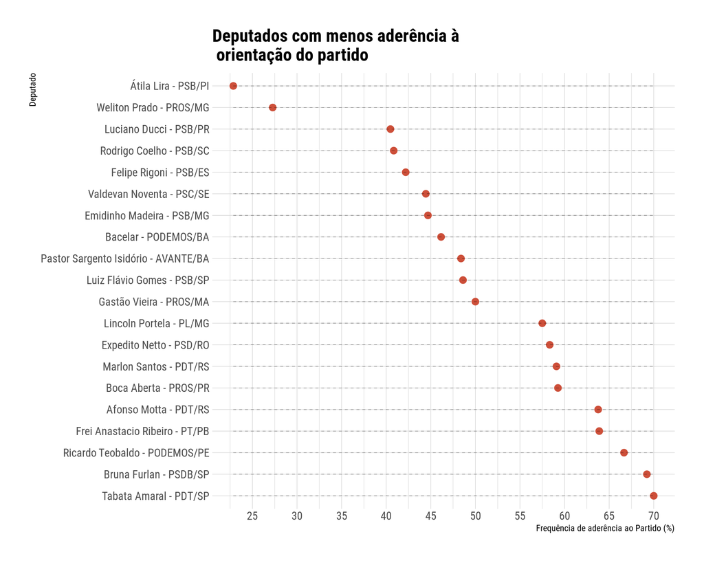

Acima estão os 20 deputados com menor aderência. A menor aderência é de Átila Lira do PSB do PI com menos de 25%.

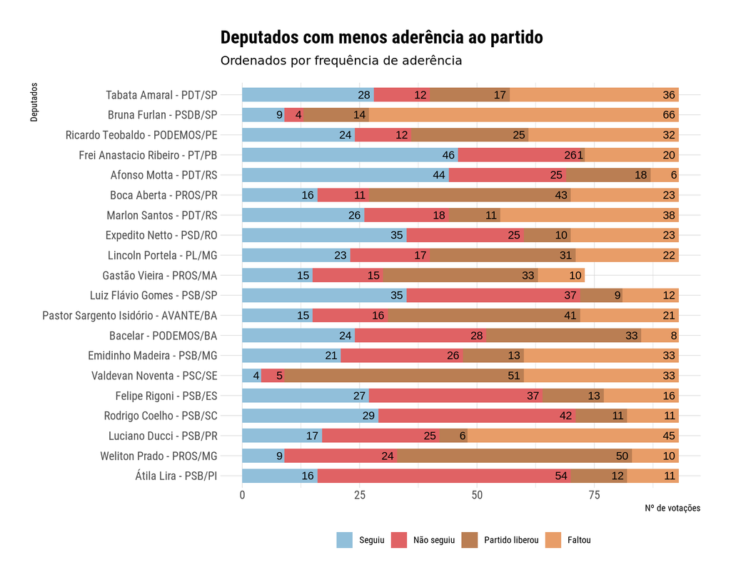

Se olharmos com mais detalhes para essa lista de 20 deputados podemos destrinchar como ocorreram as votações para cada deputado. Átila Lira, mostrado na visualização anterior com menos de 25% de aderência, teve 16 votações em que seguiu o partido, 54 em que não seguiu o partido, 12 em que o partido liberou o voto e outras 11 em que faltou.

## Aderência por partido

Subindo o nível de visão, podemos analisar a aderência dos deputados por partido. Na visualização abaixo são apresentados os pontos (deputados) e o boxplot com medidas como mediana, mínimo, máximo, dentre outras.

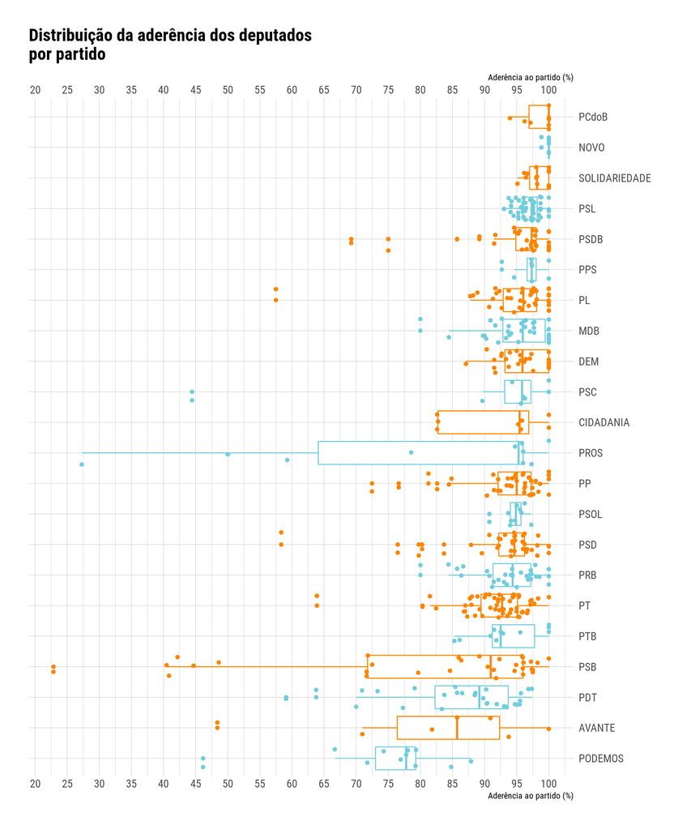

Os partidos estão ordenados pela mediana, portanto, o PCdoB é considerando o partido com deputados mais aderentes, seguido de perto pelo NOVO. As maiores amplitudes (diferença entre o máximo e o mínimo) são observadas para o PROS e o PSB. Existem deputados que nesses partidos que são muito aderentes e outros que são pouco aderentes.

As cores na visualização apenas ajudam a diferenciar deputados vizinhos um ao outro (na própria visualização).

A visualização abaixo ajuda a entender melhor a distribuição dos pontos (deputados) ao longo do eixo de aderência. A mediana é apresentada pela marca “|” e define a ordenação dos partidos.

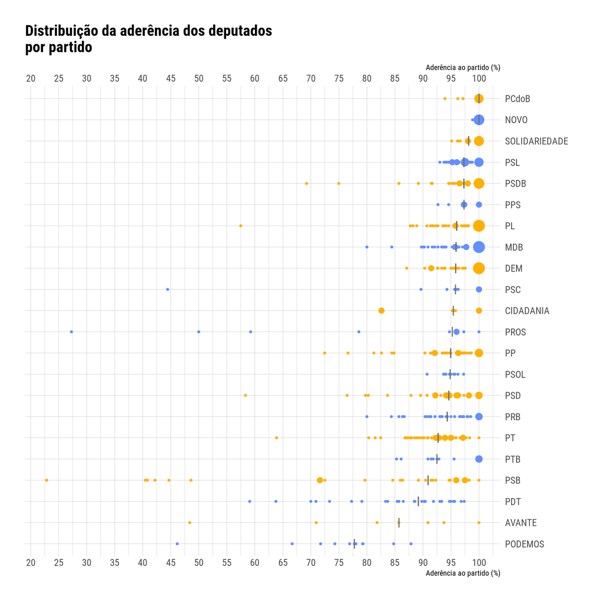

Interessante observar que o PT não apresenta uma alta mediana de aderência quando comparado a outros partidos que ganharam mais vagas no parlamento na última eleição, como o PSL. Talvez a causa disso seja a presença de todas as votações que foram votadas em 2019, sem nenhum tipo de filtro para definição das mais relevantes.

Abaixo apresentamos uma tabela (pesquisável) com os dados de todos os deputados que participaram de votações no ano de 2019.

| id | Nome | Partido | Aderência | Seguiu | Não Seguiu | Faltou | Partido liberou |
| --- | --- | --- | --- | --- | --- | --- | --- |
| 74459 | Átila Lira - PSB/PI | PSB | 22.86 | 16 | 54 | 11 | 12 |
| 160518 | Weliton Prado - PROS/MG | PROS | 27.27 | 9 | 24 | 10 | 50 |
| 178931 | Luciano Ducci - PSB/PR | PSB | 40.48 | 17 | 25 | 45 | 6 |
| 204366 | Rodrigo Coelho - PSB/SC | PSB | 40.85 | 29 | 42 | 11 | 11 |
| 204371 | Felipe Rigoni - PSB/ES | PSB | 42.19 | 27 | 37 | 16 | 13 |
| 204385 | Valdevan Noventa - PSC/SE | PSC | 44.44 | 4 | 5 | 33 | 51 |
| 161550 | Emidinho Madeira - PSB/MG | PSB | 44.68 | 21 | 26 | 33 | 13 |
| 69871 | Bacelar - PODEMOS/BA | PODEMOS | 46.15 | 24 | 28 | 8 | 33 |
| 204553 | Pastor Sargento Isidório - AVANTE/BA | AVANTE | 48.39 | 15 | 16 | 21 | 41 |
| 204543 | Luiz Flávio Gomes - PSB/SP | PSB | 48.61 | 35 | 37 | 12 | 9 |

[output cut: 504 more lines]